# Bayes Aplicado ENIGH

Hector Najera y Curtis Huffman

04/04/2023

# Hipótesis en estadística Bayesiana

Hemos visto algunas de las limitaciones del paradigma de la hipótesis nula.

- El logro educativo tiene un efecto positivo en los ingresos de los hogares (Signo)
- El efecto es proporcional según niveles educativos

Vamos a utilizar datos de la ENIGH 2018. Usaremos el nivel educativo de la jefatura del hogar y el ingreso corriente total per cápita.

```r
library(haven)
library(dplyr)
library(brms)
D<-read_dta("pobreza_18.dta")
```

Vamos a utilizar brms para las estimaciones (2.4 segundos)

```r
M1<-brm(ictpc ~ 1 + niv_edexpjh + tamhogesc, family="gaussian",
        prior = c(set_prior("normal(0,10000)", class = "b")),
        cores=4, iter=1000,
        threads = threading(14, grainsize = 100),backend = "cmdstanr", chains=2, data=D)
```

```r
summary(M1)
```

```
##  Family: gaussian
##   Links: mu = identity; sigma = identity
## Formula: ictpc ~ 1 + niv_edexpjh + tamhogesc
##    Data: D (Number of observations: 20000)
##   Draws: 2 chains, each with iter = 1000; warmup = 500; thin = 1;
##          total post-warmup draws = 1000
##
## Population-Level Effects:
##             Estimate Est.Error l-95% CI u-95% CI Rhat Bulk_ESS Tail_ESS
## Intercept    3415.30    162.08  3107.76  3726.50 1.00      861      687
## niv_edexpjh  1304.82     43.50  1218.01  1387.16 1.00      872      580
## tamhogesc    -395.51     32.57  -457.55  -331.71 1.00      968      795
##
## Family Specific Parameters:
##       Estimate Est.Error l-95% CI u-95% CI Rhat Bulk_ESS Tail_ESS
## sigma  7599.87     38.29  7523.45  7673.12 1.00     1428      762
##
## Draws were sampled using sample(hmc). For each parameter, Bulk_ESS
## and Tail_ESS are effective sample size measures, and Rhat is the potential
## scale reduction factor on split chains (at convergence, Rhat = 1).
```

```r
library(bayesplot)
library(tidybayes)
get_variables(M1)
```

```
##  [1] "b_Intercept"   "b_niv_edexpjh" "b_tamhogesc"   "sigma"
##  [5] "lprior"        "lp__"          "accept_stat__" "treedepth__"
##  [9] "stepsize__"    "divergent__"   "n_leapfrog__"  "energy__"
```

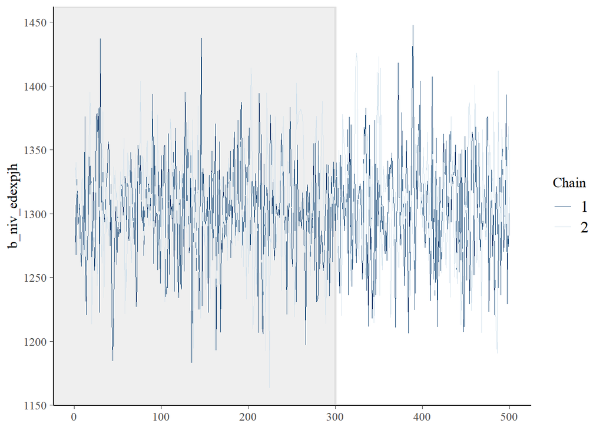

```r
color_scheme_set("mix-blue-pink")
p <- mcmc_trace(M1,  pars = c("b_niv_edexpjh" ), n_warmup = 300,
                facet_args = list(nrow = 2))
p + facet_text(size = 15)
```

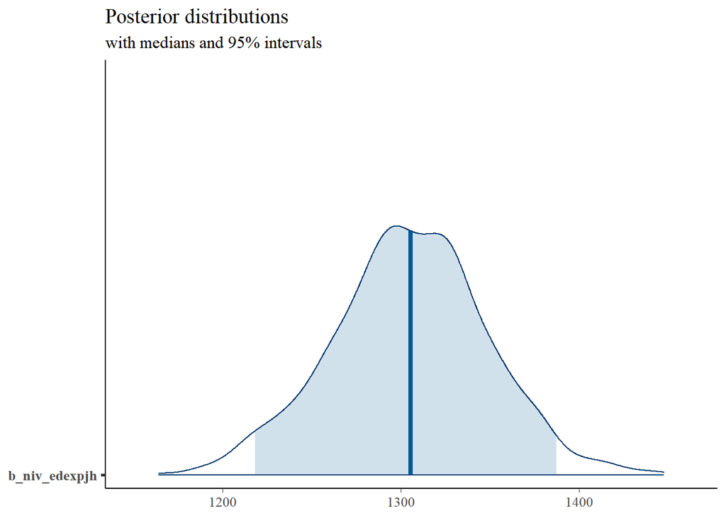

```r
library(ggplot2)
plot_title <- ggtitle("Posterior distributions",
                      "with medians and 95% intervals")
mcmc_areas(M1,
           pars = c("b_niv_edexpjh"),
           prob = 0.95) + plot_title
```

## Qué pasa ante cambios en el modelo?

El tamaño de localidad tiende a estar correlacionado con el nivel educativo entonces sería correcto ajustar el modelo incluyendo esta variable. El tamaño de localidad es, sin embargo, una variable nominal. Tenemos varias formas de incluir esta variable (crear variables binarias o utilizar la función de factor)

```r
M2<-brm(ictpc ~ 1 + niv_edexpjh + tamhogesc + factor(tam_loc), family="gaussian", iter=1000,
        prior = c(set_prior("normal(0,10000)", class = "b")),
        chains=4, cores=4,  threads = threading(14, grainsize = 100),backend = "cmdstanr", data=D)
summary(M2)
```

```
##  Family: gaussian
##   Links: mu = identity; sigma = identity
## Formula: ictpc ~ 1 + niv_edexpjh + tamhogesc + factor(tam_loc)
##    Data: D (Number of observations: 20000)
##   Draws: 4 chains, each with iter = 1000; warmup = 500; thin = 1;
##          total post-warmup draws = 2000
##
## Population-Level Effects:
##                Estimate Est.Error l-95% CI u-95% CI Rhat Bulk_ESS Tail_ESS
## Intercept       4511.98    193.39  4121.19  4899.43 1.00     2380     1445
## niv_edexpjh     1140.68     46.78  1047.61  1231.30 1.00     2628     1691
## tamhogesc       -387.82     34.08  -454.39  -322.96 1.01     2863     1403
## factortam_loc2  -861.22    170.60 -1203.55  -532.55 1.00     2558     1752
## factortam_loc3 -1287.36    174.74 -1628.63  -944.74 1.00     2496     1369
## factortam_loc4 -1437.61    131.75 -1685.53 -1173.91 1.00     2257     1784
##
## Family Specific Parameters:
##       Estimate Est.Error l-95% CI u-95% CI Rhat Bulk_ESS Tail_ESS
## sigma  7577.69     38.24  7504.57  7650.19 1.00     3602     1555
##
## Draws were sampled using sample(hmc). For each parameter, Bulk_ESS
## and Tail_ESS are effective sample size measures, and Rhat is the potential
## scale reduction factor on split chains (at convergence, Rhat = 1).
```

Voy a comparar ambas distribuciones posteriores para ver si el efecto es distinto entre un modelo y otro.

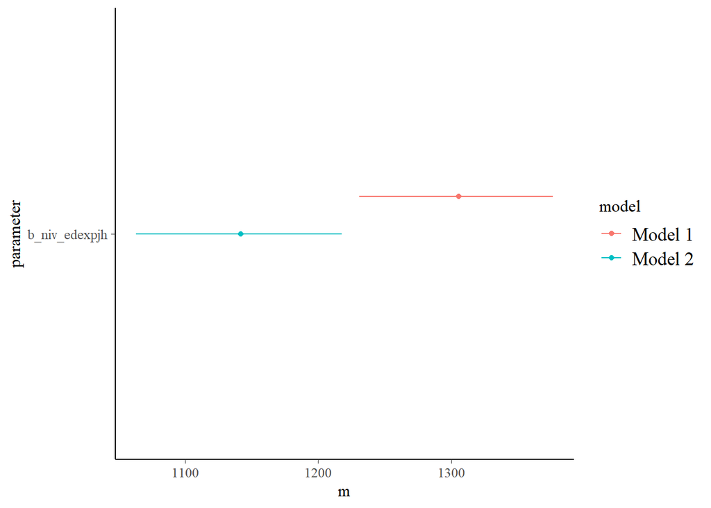

```r
combined <- rbind(mcmc_intervals_data(M1), mcmc_intervals_data(M2))
combined <- combined[c(2,8),]
combined$model <-c("Model 1", "Model 2")

# make the plot using ggplot
theme_set(bayesplot::theme_default())
pos <- position_nudge(y = ifelse(combined$model == "Model 2", 0, 0.1))
ggplot(combined, aes(x = m, y = parameter, color = model)) +
  geom_point(position = pos) +
  geom_linerange(aes(xmin = ll, xmax = hh), position = pos)
```

Efectivamente si incluyo el tamaño de localidad los resultados cambian. Ahora que pasa si me dicen en mi examen: Ya pero por lo menos ajusta tambien por entidad federativa!

```r
M3<-brm(ictpc ~ 1 + niv_edexpjh + tamhogesc + factor(tam_loc) + factor(ent),
        prior = c(set_prior("normal(0,10000)", class = "b")),
        family="gaussian", chains=4, cores=4, iter=1000,  threads = threading(14, grainsize = 100),backend = "cmdstanr", data=D)
summary(M3)
```

```
##  Family: gaussian
##   Links: mu = identity; sigma = identity
## Formula: ictpc ~ 1 + niv_edexpjh + tamhogesc + factor(tam_loc) + factor(ent)
##    Data: D (Number of observations: 20000)
##   Draws: 4 chains, each with iter = 1000; warmup = 500; thin = 1;
##          total post-warmup draws = 2000
##
## Population-Level Effects:
##                Estimate Est.Error l-95% CI u-95% CI Rhat Bulk_ESS Tail_ESS
## Intercept       4916.90    343.68  4254.15  5583.09 1.01      207      448
## niv_edexpjh     1100.07     46.57  1008.08  1190.31 1.00     1644     1462
## tamhogesc       -375.54     31.46  -438.75  -315.69 1.00     2262     1291
## factortam_loc2  -659.13    177.89 -1013.71  -307.61 1.00     1461     1154
## factortam_loc3  -944.66    184.63 -1312.96  -586.85 1.00     1342     1525
## factortam_loc4 -1207.95    138.75 -1470.96  -936.52 1.00      980     1544
## factorent2        82.52    371.44  -624.75   822.24 1.01      238      519
## factorent3      2282.92    436.20  1453.14  3157.77 1.00      346      651
## factorent4      -483.05    440.65 -1339.37   413.44 1.00      367      686
## factorent5      -126.58    391.32  -914.71   633.14 1.01      238      495
## factorent6      -534.44    402.89 -1328.10   236.85 1.01      283      568
## factorent7     -1901.41    433.91 -2716.05  -993.55 1.00      358      699
## factorent8      -326.64    379.16 -1039.08   442.65 1.01      261      650
## factorent9      -379.51    429.87 -1249.00   473.55 1.01      332      725
## factorent10    -1142.41    409.51 -1922.72  -325.95 1.00      307      673
## factorent11     -773.51    395.61 -1529.64   -14.11 1.01      270      592
## factorent12    -1441.31    427.87 -2294.07  -608.22 1.00      313      764
## factorent13     -508.36    443.66 -1347.41   363.12 1.00      330      598
## factorent14      378.92    418.76  -431.53  1205.45 1.01      296      611
## factorent15    -1241.85    397.69 -1988.19  -462.88 1.01      272      591
## factorent16     -520.50    437.96 -1387.10   353.40 1.00      318      625
## factorent17    -1450.70    435.74 -2294.44  -592.69 1.00      363      758
## factorent18      111.54    470.66  -802.24  1073.07 1.00      312      777
## factorent19      712.62    399.68   -47.73  1498.73 1.00      286      637
## factorent20    -1571.84    435.03 -2403.48  -693.92 1.00      343      834
## factorent21    -1645.20    429.34 -2460.81  -801.80 1.00      323      671
## factorent22     -315.04    385.33 -1076.02   470.36 1.01      268      539
## factorent23      418.32    465.28  -451.62  1358.70 1.00      375      614
## factorent24     -996.14    428.66 -1868.23  -116.16 1.01      331      733
## factorent25      322.93    397.34  -463.92  1107.94 1.00      247      591
## factorent26     -197.94    438.80 -1025.49   687.94 1.00      338      542
## factorent27    -1637.41    445.76 -2471.47  -756.55 1.01      326      587
## factorent28    -1078.24    456.18 -1959.23  -146.59 1.00      387      819
## factorent29    -1342.23    424.84 -2144.39  -511.97 1.00      277      407
## factorent30    -1672.82    422.92 -2462.52  -835.53 1.01      331      804
## factorent31     -610.05    406.19 -1454.33   224.12 1.01      317      598
## factorent32    -1002.34    422.57 -1813.75  -158.80 1.01      278      346
##
## Family Specific Parameters:
##       Estimate Est.Error l-95% CI u-95% CI Rhat Bulk_ESS Tail_ESS
## sigma  7537.79     37.96  7465.60  7611.79 1.00     4282     1596
##
## Draws were sampled using sample(hmc). For each parameter, Bulk_ESS
## and Tail_ESS are effective sample size measures, and Rhat is the potential
## scale reduction factor on split chains (at convergence, Rhat = 1).
```

Uh! esas posteriores no se ven muy sanas. Siempre muchas binarias son un problema. Antes de interpretar tengo que ajustar de alguna manera la estimación (priors o más cadenas)

```r
M3<-brm(ictpc ~ 1 + niv_edexpjh + tamhogesc + factor(tam_loc) + factor(ent),
        prior = c(set_prior("normal(0,10000)", class = "b")),
        family="gaussian", chains=4, cores=4, iter=1400,  threads = threading(14, grainsize = 100),backend = "cmdstanr", data=D)
summary(M3)
```

```
##  Family: gaussian
##   Links: mu = identity; sigma = identity
## Formula: ictpc ~ 1 + niv_edexpjh + tamhogesc + factor(tam_loc) + factor(ent)
##    Data: D (Number of observations: 20000)
##   Draws: 4 chains, each with iter = 1400; warmup = 700; thin = 1;
##          total post-warmup draws = 2800
##
## Population-Level Effects:
##                Estimate Est.Error l-95% CI u-95% CI Rhat Bulk_ESS Tail_ESS
## Intercept       4872.29    348.70  4236.29  5585.60 1.02      241      388
## niv_edexpjh     1100.65     45.71  1012.29  1189.19 1.00     2580     2156
## tamhogesc       -374.91     32.04  -437.74  -311.46 1.00     2818     2171
## factortam_loc2  -672.50    179.87 -1027.70  -315.25 1.00     1825     2030
## factortam_loc3  -953.49    181.19 -1295.08  -604.46 1.00     1799     2017
## factortam_loc4 -1217.67    135.02 -1474.67  -950.92 1.00     1810     2241
## factorent2       130.88    395.66  -678.05   895.19 1.02      307      620
## factorent3      2319.07    434.79  1462.65  3168.21 1.01      370      664
## factorent4      -437.90    445.63 -1291.63   413.87 1.01      377      637
## factorent5       -76.63    387.15  -855.54   665.44 1.01      311      548
## factorent6      -475.91    401.96 -1262.74   299.93 1.01      316      609
## factorent7     -1858.75    431.90 -2718.90 -1051.11 1.01      361      895
## factorent8      -276.78    381.37 -1022.72   445.81 1.02      291      428
## factorent9      -338.32    443.68 -1212.46   529.53 1.01      360      766
## factorent10    -1108.40    417.95 -1974.45  -307.72 1.01      343      714
## factorent11     -726.55    401.66 -1541.37    20.05 1.02      314      478
## factorent12    -1393.62    436.05 -2284.64  -537.88 1.01      365      737
## factorent13     -463.29    432.23 -1310.05   347.62 1.01      382      748
## factorent14      420.75    427.04  -421.33  1213.47 1.02      327      597
## factorent15    -1188.88    391.71 -1989.71  -429.62 1.02      300      465
## factorent16     -477.61    446.20 -1354.96   378.18 1.01      375      953
## factorent17    -1412.06    439.50 -2292.79  -579.01 1.01      375      849
## factorent18      151.14    452.22  -757.45  1021.75 1.01      424      756
## factorent19      757.96    411.31   -73.66  1545.12 1.02      301      424
## factorent20    -1523.13    435.34 -2413.58  -700.67 1.01      359      581
## factorent21    -1583.16    427.40 -2424.07  -785.85 1.01      338      516
## factorent22     -262.19    387.74 -1025.95   459.61 1.01      304      539
## factorent23      457.65    469.68  -448.10  1343.52 1.01      412      777
## factorent24     -952.61    412.17 -1770.81  -154.87 1.01      366      590
## factorent25      368.15    406.64  -442.61  1166.32 1.01      311      521
## factorent26     -139.67    450.93 -1056.99   701.21 1.01      399      735
## factorent27    -1593.67    440.89 -2484.82  -762.36 1.01      366      631
## factorent28    -1044.46    461.43 -1930.89  -150.65 1.01      437      917
## factorent29    -1299.24    446.59 -2193.48  -411.88 1.01      352      484
## factorent30    -1619.67    416.14 -2442.30  -839.35 1.01      347      486
## factorent31     -553.43    419.06 -1376.97   240.00 1.01      336      787
## factorent32     -948.24    427.24 -1816.34  -104.28 1.01      345      727
##
## Family Specific Parameters:
##       Estimate Est.Error l-95% CI u-95% CI Rhat Bulk_ESS Tail_ESS
## sigma  7537.55     37.37  7463.88  7613.02 1.00     4083     2001
##
## Draws were sampled using sample(hmc). For each parameter, Bulk_ESS
## and Tail_ESS are effective sample size measures, and Rhat is the potential
## scale reduction factor on split chains (at convergence, Rhat = 1).
```

Intentamos cambiar los priors

```r
prior_summary(M3)
```

```
##                         prior     class           coef group resp dpar nlpar lb
##               normal(0,10000)         b
##               normal(0,10000)         b    factorent10
##               normal(0,10000)         b    factorent11
##               normal(0,10000)         b    factorent12
##               normal(0,10000)         b    factorent13
##               normal(0,10000)         b    factorent14
##               normal(0,10000)         b    factorent15
##               normal(0,10000)         b    factorent16
##               normal(0,10000)         b    factorent17
##               normal(0,10000)         b    factorent18
##               normal(0,10000)         b    factorent19
##               normal(0,10000)         b     factorent2
##               normal(0,10000)         b    factorent20
##               normal(0,10000)         b    factorent21
##               normal(0,10000)         b    factorent22
##               normal(0,10000)         b    factorent23
##               normal(0,10000)         b    factorent24
##               normal(0,10000)         b    factorent25
##               normal(0,10000)         b    factorent26
##               normal(0,10000)         b    factorent27
##               normal(0,10000)         b    factorent28
##               normal(0,10000)         b    factorent29
##               normal(0,10000)         b     factorent3
##               normal(0,10000)         b    factorent30
##               normal(0,10000)         b    factorent31
##               normal(0,10000)         b    factorent32
##               normal(0,10000)         b     factorent4
##               normal(0,10000)         b     factorent5
##               normal(0,10000)         b     factorent6
##               normal(0,10000)         b     factorent7
##               normal(0,10000)         b     factorent8
##               normal(0,10000)         b     factorent9
##               normal(0,10000)         b factortam_loc2
##               normal(0,10000)         b factortam_loc3
##               normal(0,10000)         b factortam_loc4
##               normal(0,10000)         b    niv_edexpjh
##               normal(0,10000)         b      tamhogesc
##  student_t(3, 2753.2, 1865.8) Intercept
##       student_t(3, 0, 1865.8)     sigma                                       0
```

[output cut: 25 more lines]

```
##     (vectorized)
##     (vectorized)
##     (vectorized)
##     (vectorized)
##     (vectorized)
##     (vectorized)
##     (vectorized)
##     (vectorized)
##     (vectorized)
##     (vectorized)
##     (vectorized)
##     (vectorized)
##     (vectorized)
##          default
##          default
```

```r
M3<-brm(ictpc ~ 1 + niv_edexpjh + tamhogesc + factor(tam_loc) + factor(ent),
        prior = c(set_prior("normal(0,1000)", class = "b"),
                  set_prior("student_t(3, 0, 2000)", class = "Intercept")),
        family="gaussian", chains=4, cores=4, iter=1400,  threads = threading(14, grainsize = 100),backend = "cmdstanr", data=D)
summary(M3)
```

```
##  Family: gaussian
##   Links: mu = identity; sigma = identity
## Formula: ictpc ~ 1 + niv_edexpjh + tamhogesc + factor(tam_loc) + factor(ent)
##    Data: D (Number of observations: 20000)
##   Draws: 4 chains, each with iter = 1400; warmup = 700; thin = 1;
##          total post-warmup draws = 2800
##
## Population-Level Effects:
##                Estimate Est.Error l-95% CI u-95% CI Rhat Bulk_ESS Tail_ESS
## Intercept       4471.00    241.29  3994.82  4942.08 1.00     1126     1795
## niv_edexpjh     1106.75     46.50  1017.78  1196.69 1.00     3541     2278
## tamhogesc       -374.17     31.79  -434.86  -312.08 1.00     4112     2272
## factortam_loc2  -657.57    179.73 -1020.34  -302.22 1.00     2829     2126
## factortam_loc3  -951.78    180.22 -1317.23  -605.30 1.00     2539     2255
## factortam_loc4 -1204.93    133.79 -1462.72  -938.92 1.00     2354     2016
## factorent2       478.08    280.30   -80.43  1020.06 1.00     1162     1943
## factorent3      2452.60    336.25  1790.86  3109.86 1.00     1885     1962
## factorent4       -58.28    353.56  -760.56   648.65 1.00     1950     2025
## factorent5       285.24    294.81  -278.59   862.75 1.00     1404     1655
## factorent6      -100.92    314.45  -715.05   524.32 1.00     1666     2035
## factorent7     -1335.97    350.32 -2026.88  -637.20 1.00     1709     1774
## factorent8        97.31    275.63  -446.76   638.94 1.00     1323     1716
## factorent9        37.77    342.08  -630.17   703.77 1.00     2073     1823
## factorent10     -666.18    312.50 -1266.82   -55.71 1.00     1650     1914
## factorent11     -324.29    299.56  -932.87   258.03 1.00     1550     1948
## factorent12     -924.75    333.94 -1579.23  -264.06 1.00     1849     1910
## factorent13      -66.79    352.67  -745.72   614.81 1.00     1828     1941
## factorent14      731.60    335.14    86.59  1394.17 1.00     1841     1838
## factorent15     -765.82    290.33 -1322.43  -197.73 1.00     1491     1840
## factorent16      -85.07    347.90  -785.01   560.20 1.00     1570     1884
## factorent17     -927.14    350.74 -1607.89  -230.26 1.00     1683     1867
## factorent18      476.29    372.04  -238.32  1212.86 1.00     1860     1784
## factorent19     1055.94    305.73   466.51  1649.27 1.00     1332     1686
## factorent20    -1044.47    331.42 -1717.80  -415.01 1.00     1838     1821
## factorent21    -1077.25    339.38 -1738.71  -407.78 1.00     1644     1985
## factorent22      107.57    292.99  -463.06   675.51 1.00     1445     1774
## factorent23      745.31    365.30    39.73  1460.41 1.00     1891     1760
## factorent24     -519.28    329.12 -1170.46   114.64 1.00     1532     2089
## factorent25      706.21    306.69   118.24  1314.93 1.00     1622     1657
## factorent26      215.82    339.66  -447.84   878.02 1.00     1624     2006
## factorent27    -1090.40    348.76 -1780.06  -424.69 1.00     1777     1789
## factorent28     -590.53    361.92 -1297.92   139.81 1.00     1967     1971
## factorent29     -832.92    336.25 -1481.52  -179.06 1.00     1570     1793
## factorent30    -1131.09    330.48 -1765.18  -480.20 1.00     1700     1825
## factorent31     -157.32    310.02  -779.48   466.22 1.00     1817     2116
## factorent32     -512.38    318.86 -1114.60   135.97 1.00     1624     1930
##
## Family Specific Parameters:
##       Estimate Est.Error l-95% CI u-95% CI Rhat Bulk_ESS Tail_ESS
## sigma  7538.20     37.07  7463.46  7613.42 1.00     6448     1857
##
## Draws were sampled using sample(hmc). For each parameter, Bulk_ESS
## and Tail_ESS are effective sample size measures, and Rhat is the potential
## scale reduction factor on split chains (at convergence, Rhat = 1).
```

Ahora comparo los tres modelos. Concluyo que mi conclusión se sostiene.

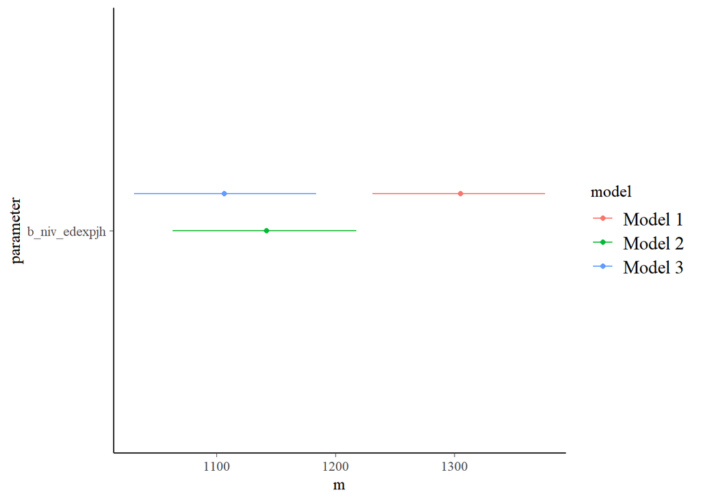

```r
combined <- rbind(mcmc_intervals_data(M1), mcmc_intervals_data(M2),  mcmc_intervals_data(M3))
combined <- subset(combined, parameter=="b_niv_edexpjh")
combined$model <-c("Model 1", "Model 2", "Model 3")

# make the plot using ggplot
theme_set(bayesplot::theme_default())
pos <- position_nudge(y = ifelse(combined$model == "Model 2", 0, 0.1))
ggplot(combined, aes(x = m, y = parameter, color = model)) +
  geom_point(position = pos) +
  geom_linerange(aes(xmin = ll, xmax = hh), position = pos)
```

## Si pero… qué tal si el efecto no es proporcional por nivel educativo. Tengo 5 Niveles.

```r
M4<-brm(ictpc ~ 1 + factor(niv_edexpjh) + tamhogesc + factor(tam_loc) + factor(ent),
         prior = c(set_prior("normal(0,1000)", class = "b"),
                  set_prior("student_t(3, 0, 2000)", class = "Intercept")),
        family="gaussian", chains=4, cores=4, iter=1500,  threads = threading(8, grainsize = 100),backend = "cmdstanr", data=D)
summary(M4)
```

```
##  Family: gaussian
##   Links: mu = identity; sigma = identity
## Formula: ictpc ~ 1 + factor(niv_edexpjh) + tamhogesc + factor(tam_loc) + factor(ent)
##    Data: D (Number of observations: 20000)
##   Draws: 4 chains, each with iter = 1500; warmup = 750; thin = 1;
##          total post-warmup draws = 3000
##
## Population-Level Effects:
##                    Estimate Est.Error l-95% CI u-95% CI Rhat Bulk_ESS Tail_ESS
## Intercept           5311.93    258.74  4823.72  5817.57 1.00      877     1619
## factorniv_edexpjh1    78.34    158.94  -229.87   389.04 1.00     2013     2284
## factorniv_edexpjh2   323.71    145.93    38.38   602.10 1.00     1841     2130
## factorniv_edexpjh3  1863.93    183.14  1503.59  2218.33 1.00     2076     2422
## factorniv_edexpjh4  5574.27    212.65  5158.88  5995.11 1.00     1943     2227
## tamhogesc           -365.14     32.06  -427.29  -301.58 1.00     3679     1986
## factortam_loc2      -539.69    184.04  -893.31  -176.65 1.00     2836     2402
## factortam_loc3      -821.52    177.37 -1176.57  -475.02 1.00     2918     2310
## factortam_loc4     -1130.45    134.53 -1396.37  -872.64 1.00     2326     2383
## factorent2           499.89    291.30   -76.23  1083.37 1.00     1068     1979
## factorent3          2526.92    330.36  1887.46  3144.78 1.00     1419     2010
## factorent4           -92.75    347.41  -769.11   582.69 1.00     1391     1820
## factorent5           411.25    292.90  -134.20  1003.74 1.00     1132     1333
## factorent6          -166.14    313.05  -760.90   442.69 1.00     1264     2376
## factorent7         -1512.40    341.14 -2173.03  -837.30 1.00     1447     1495
## factorent8            47.17    286.82  -509.35   623.46 1.00     1165     1587
## factorent9            68.65    342.38  -597.98   743.94 1.00     1261     1925
## factorent10         -620.81    319.99 -1241.06    11.73 1.00     1296     1892
## factorent11         -405.21    306.68 -1011.09   181.03 1.00     1197     1426
## factorent12        -1121.61    341.77 -1794.51  -463.76 1.00     1557     1822
## factorent13          -29.35    350.64  -706.25   665.90 1.00     1477     1578
## factorent14          584.02    338.13   -88.01  1225.09 1.00     1435     2153
## factorent15         -653.13    298.95 -1223.93   -69.91 1.00     1108     1603
## factorent16         -199.00    352.67  -878.88   521.77 1.00     1769     1889
## factorent17         -904.20    349.67 -1575.95  -222.11 1.00     1355     2199
## factorent18          459.12    349.47  -228.05  1139.60 1.00     1662     2328
## factorent19         1131.99    309.29   525.56  1745.38 1.00     1300     1658
## factorent20        -1301.65    343.94 -1968.00  -621.99 1.00     1459     1849
## factorent21        -1154.53    340.21 -1806.48  -482.46 1.00     1552     2114
## factorent22          165.86    295.59  -417.32   750.89 1.00     1201     1694
## factorent23          794.53    364.96    72.17  1496.90 1.00     1692     2090
## factorent24         -557.27    337.01 -1213.27   124.36 1.00     1500     1868
## factorent25          511.21    314.62   -93.20  1130.09 1.00     1360     2086
## factorent26          234.69    348.21  -449.65   908.31 1.00     1363     1839
## factorent27        -1127.83    359.74 -1806.48  -412.33 1.00     1562     1956
## factorent28         -542.62    367.77 -1257.55   188.86 1.00     1824     1887
## factorent29         -835.28    350.18 -1542.36  -156.51 1.00     1485     1801
## factorent30        -1352.28    336.33 -2007.19  -704.42 1.00     1522     2090
## factorent31         -261.79    319.31  -867.47   349.28 1.00     1278     1770
## factorent32         -520.86    327.86 -1174.00   102.68 1.00     1389     1834
##
## Family Specific Parameters:
##       Estimate Est.Error l-95% CI u-95% CI Rhat Bulk_ESS Tail_ESS
## sigma  7474.91     36.71  7400.89  7549.03 1.00     5751     1684
##
## Draws were sampled using sample(hmc). For each parameter, Bulk_ESS
## and Tail_ESS are effective sample size measures, and Rhat is the potential
## scale reduction factor on split chains (at convergence, Rhat = 1).
```

## ¿Es un buen modelo?

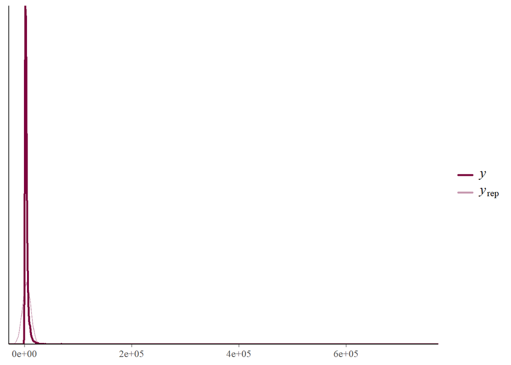

```r
pp_check(M4)
```

# ¿Ideas?

Recuerden que Bayes es mucho más flexible. Vamos a usar `family=skew_normal()`.

```r
M5<-brm(ictpc ~ 1 + factor(niv_edexpjh) + tamhogesc + factor(tam_loc) + factor(ent), family=skew_normal(),
                   prior = c(set_prior("normal(0,1000)", class = "b"),
                  set_prior("student_t(3, 0, 2000)", class = "Intercept")),
          iter=1200, cores = 14, chains=2, init=0, data=D, threads = threading(14, grainsize = 100),backend = "cmdstanr")
```

```r
summary(M5)
```

```
##  Family: skew_normal
##   Links: mu = identity; sigma = identity; alpha = identity
## Formula: ictpc ~ 1 + factor(niv_edexpjh) + tamhogesc + factor(tam_loc) + factor(ent)
##    Data: D (Number of observations: 20000)
##   Draws: 2 chains, each with iter = 1200; warmup = 600; thin = 1;
##          total post-warmup draws = 1200
##
## Population-Level Effects:
##                    Estimate Est.Error l-95% CI u-95% CI Rhat Bulk_ESS Tail_ESS
## Intercept           7331.81    112.94  7087.97  7537.73 1.02      261      246
## factorniv_edexpjh1    78.12     50.75   -18.56   176.71 1.00      933     1012
## factorniv_edexpjh2   227.30     48.25   134.18   320.12 1.00      845      913
## factorniv_edexpjh3   413.06     60.95   297.05   535.43 1.00     1039      922
## factorniv_edexpjh4  1136.02     59.58  1023.72  1254.28 1.01      858      911
## tamhogesc            -35.50     11.34   -57.59   -13.89 1.00     1395      857
## factortam_loc2      -232.99     59.95  -350.05  -112.84 1.00     1211      861
## factortam_loc3      -315.49     56.19  -427.77  -204.38 1.01     1015      892
## factortam_loc4      -466.57     43.85  -550.73  -379.94 1.00      874      833
## factorent2            26.69    122.72  -205.29   272.41 1.02      348      246
## factorent3           192.74    120.97   -28.94   426.09 1.02      305      369
## factorent4          -192.19    132.59  -454.51    65.58 1.01      398      423
## factorent5            44.49    119.27  -192.07   278.06 1.01      362      418
## factorent6           -95.00    120.16  -324.02   136.23 1.02      336      355
## factorent7          -493.31    137.89  -773.94  -219.56 1.01      378      389
## factorent8          -123.15    107.42  -313.42   103.47 1.02      295      300
## factorent9           110.92    130.86  -163.21   372.29 1.01      358      299
## factorent10         -372.76    136.76  -637.60   -96.23 1.01      429      397
## factorent11          -38.26    117.18  -267.60   189.75 1.01      307      322
## factorent12         -448.09    136.32  -709.82  -171.16 1.01      412      307
## factorent13           66.62    127.90  -193.25   319.32 1.01      361      378
## factorent14          249.77    119.16    10.59   474.42 1.02      294      264
## factorent15         -108.28    123.02  -363.52   132.65 1.01      350      387
## factorent16          -51.56    131.13  -302.95   210.63 1.02      333      299
## factorent17         -378.23    138.95  -638.62   -95.92 1.01      411      321
## factorent18           -6.99    126.63  -262.86   246.59 1.02      361      312
## factorent19          444.26    116.24   226.89   681.93 1.02      298      313
## factorent20         -403.91    136.63  -685.10  -161.39 1.01      397      333
## factorent21         -207.47    132.84  -462.01    61.28 1.01      353      399
## factorent22          142.66    112.57   -67.98   381.20 1.01      330      289
## factorent23          101.93    138.07  -172.05   391.50 1.02      360      345
## factorent24         -215.15    131.78  -479.25    49.22 1.02      366      393
## factorent25          202.51    113.12   -10.25   427.91 1.02      303      359
## factorent26           -4.02    129.37  -245.61   260.20 1.01      397      413
## factorent27         -211.30    139.17  -495.34    73.80 1.01      492      399
## factorent28         -260.55    135.27  -514.78     6.51 1.01      362      314
## factorent29         -334.18    134.77  -597.74   -69.61 1.01      406      487
## factorent30         -359.26    131.68  -625.97  -101.25 1.01      375      344
## factorent31          -73.83    123.59  -313.94   176.32 1.02      327      371
## factorent32         -144.94    128.49  -386.41   113.15 1.01      354      369
##
## Family Specific Parameters:
##       Estimate Est.Error l-95% CI u-95% CI Rhat Bulk_ESS Tail_ESS
## sigma  5128.94     25.69  5079.35  5179.25 1.00     1321      824
## alpha    28.83      1.42    26.16    31.66 1.00     1088      733
##
## Draws were sampled using sample(hmc). For each parameter, Bulk_ESS
## and Tail_ESS are effective sample size measures, and Rhat is the potential
## scale reduction factor on split chains (at convergence, Rhat = 1).
```

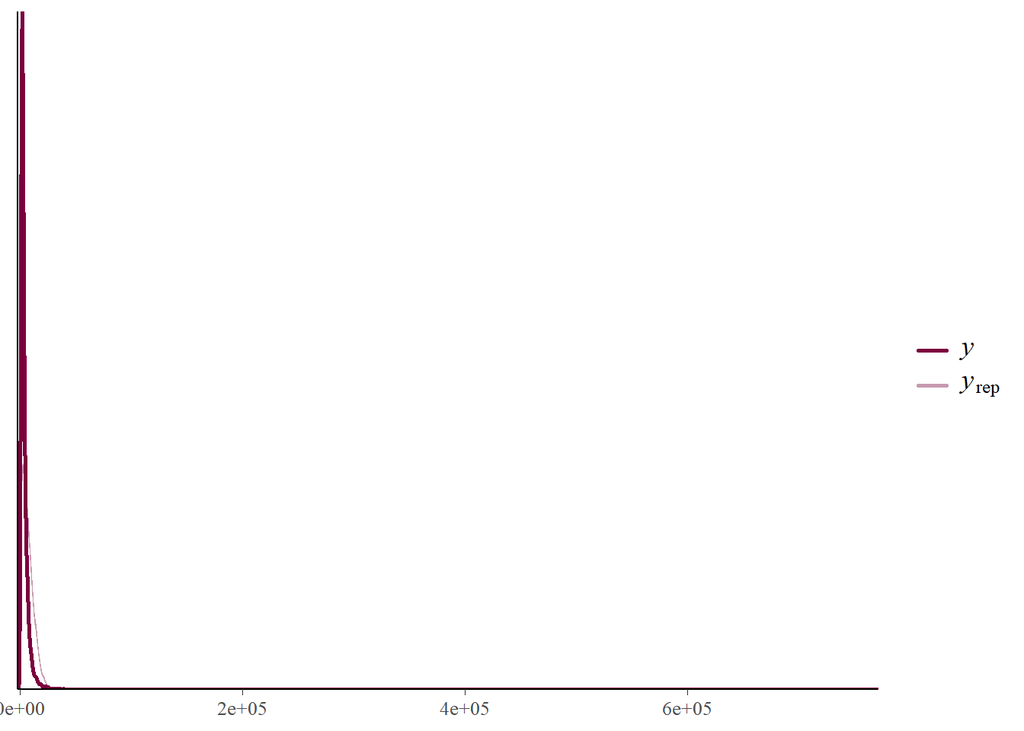

```r
pp_check(M5)
```

# Log-normal

```r
D$ictpc2<-ifelse(D$ictpc==0,NA,D$ictpc)
M6<-brm(ictpc2 ~ 1 + factor(niv_edexpjh) + tamhogesc + factor(tam_loc) + factor(ent), family=lognormal(),
                   prior = c(set_prior("normal(0,1.5)", class = "b"),
                  set_prior("normal(0,1.5)", class = "Intercept")),
          iter=1400, cores = 14, chains=2, init=0, data=D, threads = threading(14, grainsize = 100),backend = "cmdstanr")
```

Los priors necesitan re-escalarse debido al cambio en la escala de la variable dependiente.

```r
M7<-brm(ictpc2 ~ 1 + factor(niv_edexpjh) + tamhogesc + factor(tam_loc) + factor(ent), family=lognormal(),
                   prior = c(set_prior("student_t(2, 0, .5)", class = "b"),
                  set_prior("student_t(3, 0, 3)", class = "Intercept")),
          iter=1400, cores = 14, chains=2, init=0, data=D, threads = threading(14, grainsize = 100),backend = "cmdstanr")
```

```r
summary(M6)
```

```
##  Family: lognormal
##   Links: mu = identity; sigma = identity
## Formula: ictpc2 ~ 1 + factor(niv_edexpjh) + tamhogesc + factor(tam_loc) + factor(ent)
##    Data: D (Number of observations: 19993)
##   Draws: 2 chains, each with iter = 1400; warmup = 700; thin = 1;
##          total post-warmup draws = 1400
##
## Population-Level Effects:
##                    Estimate Est.Error l-95% CI u-95% CI Rhat Bulk_ESS Tail_ESS
## Intercept              8.37      0.03     8.31     8.44 1.04       82      195
## factorniv_edexpjh1     0.09      0.01     0.06     0.12 1.00      791      722
## factorniv_edexpjh2     0.19      0.01     0.16     0.21 1.00      691      907
## factorniv_edexpjh3     0.44      0.02     0.40     0.47 1.00      632      532
## factorniv_edexpjh4     0.91      0.02     0.87     0.95 1.00      757      711
## tamhogesc             -0.06      0.00    -0.07    -0.06 1.00     3167     1073
## factortam_loc2        -0.11      0.02    -0.14    -0.08 1.01      705     1174
## factortam_loc3        -0.19      0.02    -0.22    -0.15 1.00      927     1016
## factortam_loc4        -0.41      0.01    -0.44    -0.39 1.00      680      885
## factorent2             0.06      0.04    -0.02     0.13 1.03       86      253
## factorent3             0.15      0.04     0.07     0.23 1.04       51      302
## factorent4            -0.23      0.04    -0.31    -0.15 1.02      116      372
## factorent5            -0.03      0.04    -0.10     0.04 1.03       85      290
## factorent6            -0.12      0.04    -0.20    -0.04 1.03       83      304
## factorent7            -0.83      0.04    -0.91    -0.75 1.03      100      351
## factorent8            -0.16      0.03    -0.23    -0.09 1.03       97      222
## factorent9            -0.12      0.04    -0.20    -0.04 1.03      107      456
## factorent10           -0.27      0.04    -0.35    -0.20 1.02      104      348
## factorent11           -0.26      0.04    -0.34    -0.20 1.03      102      282
## factorent12           -0.66      0.04    -0.74    -0.58 1.02      118      436
## factorent13           -0.17      0.04    -0.25    -0.08 1.03      107      379
## factorent14           -0.03      0.04    -0.11     0.04 1.03      115      362
## factorent15           -0.30      0.04    -0.37    -0.23 1.03       93      174
## factorent16           -0.25      0.04    -0.33    -0.17 1.02      110      354
## factorent17           -0.40      0.04    -0.48    -0.32 1.04       56      224
## factorent18           -0.12      0.04    -0.21    -0.04 1.01      134      357
## factorent19            0.13      0.04     0.06     0.20 1.03       90      265
## factorent20           -0.66      0.04    -0.73    -0.58 1.03      100      357
## factorent21           -0.48      0.04    -0.56    -0.41 1.03      107      400
## factorent22           -0.04      0.04    -0.11     0.03 1.03       81      241
## factorent23            0.01      0.04    -0.07     0.09 1.02      172      484
## factorent24           -0.35      0.04    -0.43    -0.28 1.02      103      317
## factorent25           -0.11      0.04    -0.19    -0.04 1.03      107      305
## factorent26           -0.12      0.04    -0.20    -0.05 1.02      120      466
## factorent27           -0.45      0.04    -0.54    -0.38 1.03       92      263
## factorent28           -0.35      0.04    -0.45    -0.27 1.02      168      405
## factorent29           -0.33      0.04    -0.40    -0.25 1.02      136      298
## factorent30           -0.63      0.04    -0.71    -0.55 1.02      127      415
## factorent31           -0.20      0.04    -0.28    -0.13 1.03       82      274
## factorent32           -0.37      0.04    -0.45    -0.30 1.03      108      371
##
## Family Specific Parameters:
##       Estimate Est.Error l-95% CI u-95% CI Rhat Bulk_ESS Tail_ESS
## sigma     0.68      0.00     0.67     0.68 1.00     1846     1138
##
## Draws were sampled using sample(hmc). For each parameter, Bulk_ESS
## and Tail_ESS are effective sample size measures, and Rhat is the potential
## scale reduction factor on split chains (at convergence, Rhat = 1).
```

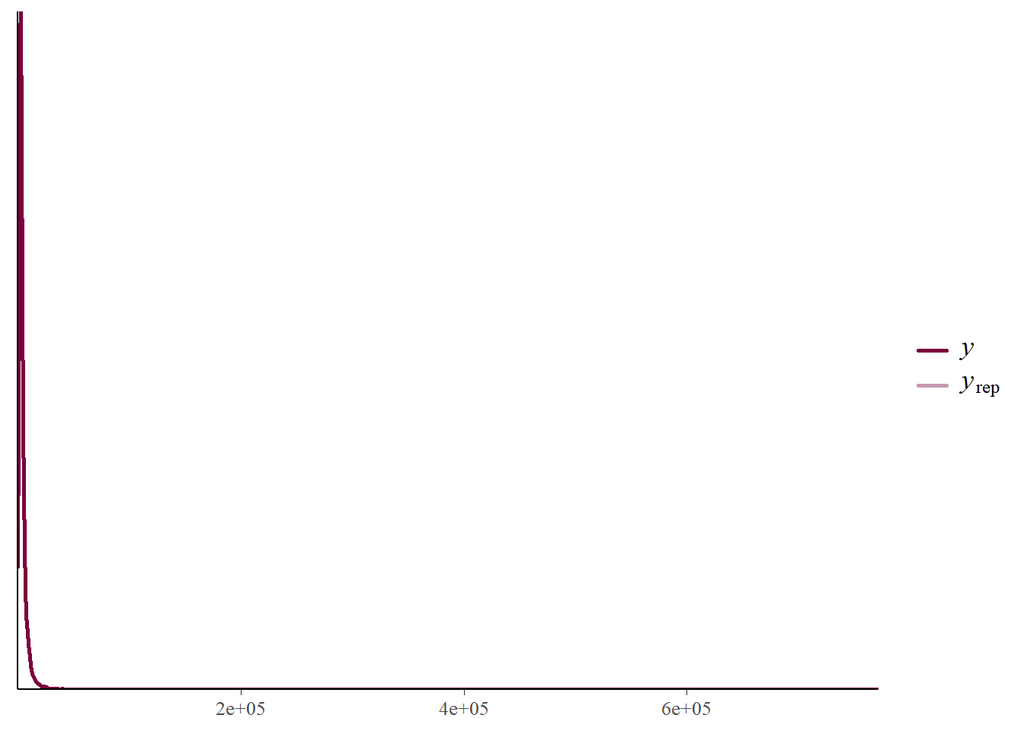

```r
pp_check(M6)
```

```r
M7<-brm(ictpc2 ~ 1 + factor(niv_edexpjh) + tamhogesc + factor(tam_loc) + factor(ent), family=lognormal(),
                   prior = c(set_prior("student_t(2, 0, .5)", class = "b"),
                  set_prior("student_t(3, 0, 3)", class = "Intercept")),
          control = list(adapt_delta = .99, max_treedepth=14),
          iter=1400, cores = 14, chains=2, init=0, data=D, threads = threading(14, grainsize = 100),backend = "cmdstanr")
```

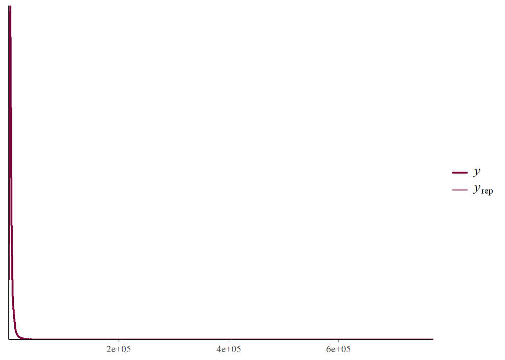

```r
pp_check(M7)
```

# Prubeas de hipótesis

Hipótesis con la función `hypothesis`. Primero definimos la hipótesis. Por ejemplo, que los efectos son iguales.

```r
parnames(M5)
```

```
##  [1] "b_Intercept"          "b_factorniv_edexpjh1" "b_factorniv_edexpjh2"
##  [4] "b_factorniv_edexpjh3" "b_factorniv_edexpjh4" "b_tamhogesc"
##  [7] "b_factortam_loc2"     "b_factortam_loc3"     "b_factortam_loc4"
## [10] "b_factorent2"         "b_factorent3"         "b_factorent4"
## [13] "b_factorent5"         "b_factorent6"         "b_factorent7"
## [16] "b_factorent8"         "b_factorent9"         "b_factorent10"
## [19] "b_factorent11"        "b_factorent12"        "b_factorent13"
## [22] "b_factorent14"        "b_factorent15"        "b_factorent16"
## [25] "b_factorent17"        "b_factorent18"        "b_factorent19"
## [28] "b_factorent20"        "b_factorent21"        "b_factorent22"
## [31] "b_factorent23"        "b_factorent24"        "b_factorent25"
## [34] "b_factorent26"        "b_factorent27"        "b_factorent28"
## [37] "b_factorent29"        "b_factorent30"        "b_factorent31"
## [40] "b_factorent32"        "sigma"                "alpha"
## [43] "lprior"               "lp__"
```

```r
## perform two-sided hypothesis testing
(hyp1 <- hypothesis(M5, "factorniv_edexpjh1 = factorniv_edexpjh4"))
```

```
## Hypothesis Tests for class b:
##                 Hypothesis Estimate Est.Error CI.Lower CI.Upper Evid.Ratio
## 1 (factorniv_edexpj... = 0 -1057.89     58.82 -1176.61  -943.64         NA
##   Post.Prob Star
## 1        NA    *
## ---
## 'CI': 90%-CI for one-sided and 95%-CI for two-sided hypotheses.
## '*': For one-sided hypotheses, the posterior probability exceeds 95%;
## for two-sided hypotheses, the value tested against lies outside the 95%-CI.
## Posterior probabilities of point hypotheses assume equal prior probabilities.
```

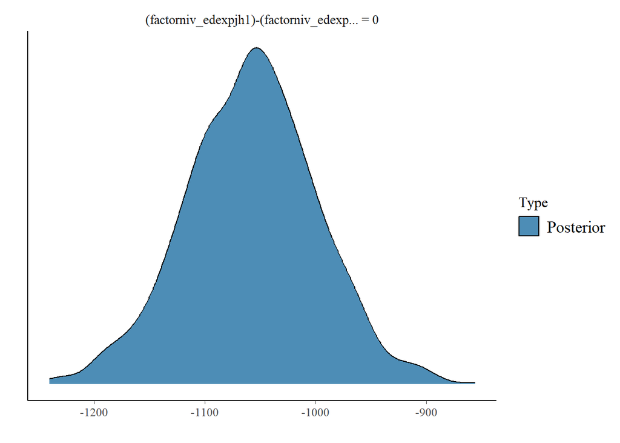

```r
plot(hyp1)
```

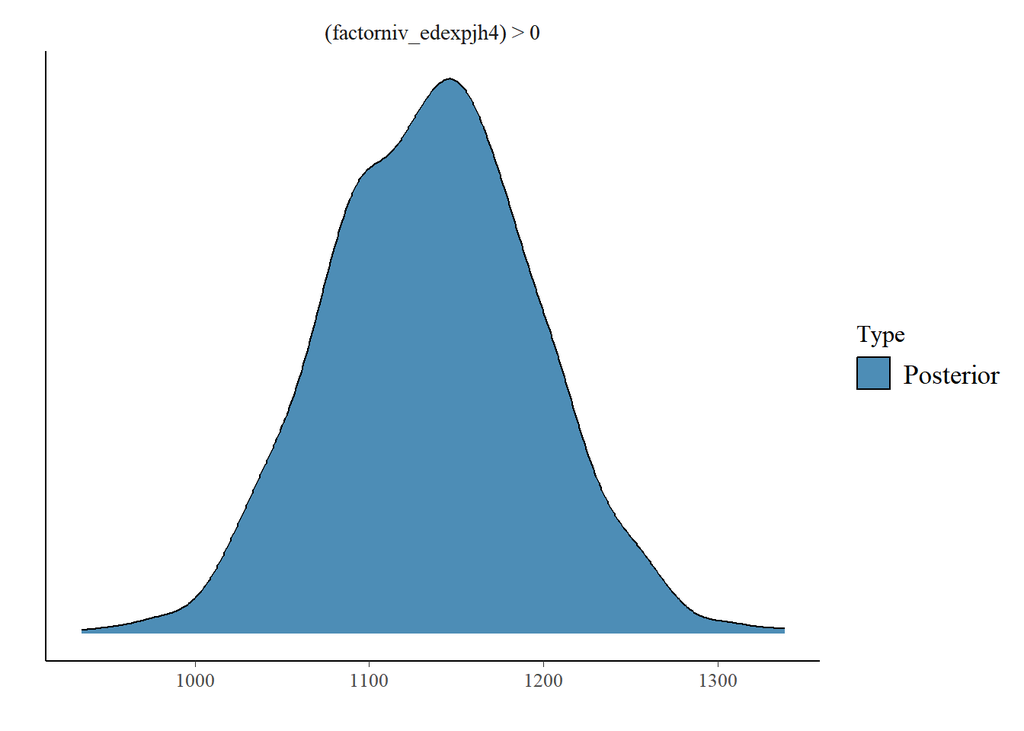

```r
hyp2 <-hypothesis(M5, "factorniv_edexpjh4 > 0", alpha = 0.01)
plot(hyp2)
```

Qué tal y si nos preguntamos que ir a la universidad incrementa en 800 pesos per capita el ingreso del hogar (respecto a no terminar la primaria).

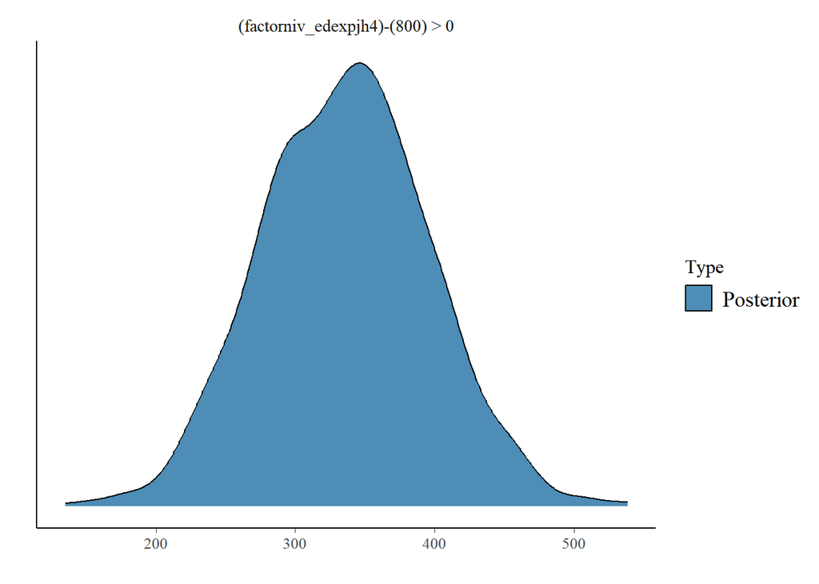

```r
hyp3 <-hypothesis(M5, "factorniv_edexpjh4 > 800", alpha = 0.01)
plot(hyp3)
```

Es igual el efecto entre CDMX y NL?

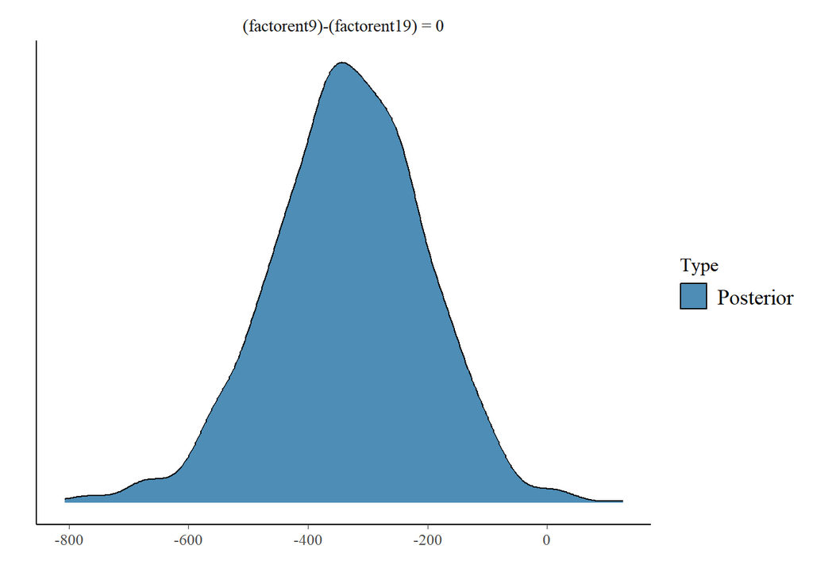

```r
hyp4 <-hypothesis(M5, "factorent9 = factorent19", alpha = 0.01)
plot(hyp4)
```